# **Simple Stock Analysis for Long Term Investment**

#### Coming from a spirit to inform Indonesian people about investment and the leverage of money, Author built an [investing calculator website](https://investasi.jimmyganteng.com). The calculator shows how to invest while also paying an installment. For further details, feel free to check [the documentation](https://github.com/Fazatholomew/sempoainvest).

## A. Question(s) and Goal(s)

- If we wanted to invest in a long term interval, how could we reduce the risk while maximizing the return of investment?
- What is the best way to pick stocks based on criteria from the previous question?

The goal of this analysis is to come up with a group of stocks that are relatively reliable on giving return of investment given the risk involved. The analysis should provide a substantial data to confidently use the stocks for further analysis or use.

## B. Data Collection

There are a lot of ways to gather historical stock prices with its fundamentals. For this specific analysis, [Pandas](https://pandas.pydata.org/about/) provided a library to fetch data from multiple sources. The library is called [Pandas Data Reader](https://pandas-datareader.readthedocs.io/en/latest/). The library is a wrapper to fetch data such as historical stock prices, GDP of nations, The World economics data, etc. This analysis specifically, Yahoo Finance data is used because it is free and has a huge database of stocks. By avoiding manual work, such as downloading CSV files, the analysis can be used for as many stocks as possible.

```python
import pandas_datareader.data as web
```

For starters, let's analyze S&P 500 (SPY). As the ETF is famous for its reliability to indicate the world's economy. To make the data more relevant, 10 years worth of data is fetched.

```python
spy = web.DataReader('SPY', 'yahoo', start='2011-01-01', end='2021-01-01')
spy
```

| Date | High | Low | Open | Close | Volume | Adj Close |
| --- | --- | --- | --- | --- | --- | --- |
| 2011-01-03 | 127.599998 | 125.699997 | 126.709999 | 127.050003 | 138725200.0 | 104.119293 |
| 2011-01-04 | 127.370003 | 126.190002 | 127.330002 | 126.980003 | 137409700.0 | 104.061905 |
| 2011-01-05 | 127.720001 | 126.459999 | 126.580002 | 127.639999 | 133975300.0 | 104.602806 |
| 2011-01-06 | 127.830002 | 127.010002 | 127.690002 | 127.389999 | 122519000.0 | 104.397934 |
| 2011-01-07 | 127.769997 | 126.150002 | 127.559998 | 127.139999 | 156034600.0 | 104.193031 |
| ... | ... | ... | ... | ... | ... | ... |
| 2020-12-24 | 369.029999 | 367.450012 | 368.079987 | 369.000000 | 26457900.0 | 369.000000 |
| 2020-12-28 | 372.589996 | 371.070007 | 371.739990 | 372.170013 | 39000400.0 | 372.170013 |
| 2020-12-29 | 374.000000 | 370.829987 | 373.809998 | 371.459991 | 53680500.0 | 371.459991 |
| 2020-12-30 | 373.100006 | 371.570007 | 372.339996 | 371.989990 | 49455300.0 | 371.989990 |
| 2020-12-31 | 374.660004 | 371.230011 | 371.779999 | 373.880005 | 78469000.0 | 373.880005 |

2517 rows × 6 columns

```python
spy = spy[['Adj Close']].rename(columns={'Adj Close': 'Price'}).copy()
spy.tail(10)
```

| Date | Price |
| --- | --- |
| 2020-12-17 | 370.660004 |
| 2020-12-18 | 369.179993 |
| 2020-12-21 | 367.859985 |
| 2020-12-22 | 367.239990 |
| 2020-12-23 | 367.570007 |
| 2020-12-24 | 369.000000 |
| 2020-12-28 | 372.170013 |
| 2020-12-29 | 371.459991 |
| 2020-12-30 | 371.989990 |
| 2020-12-31 | 373.880005 |

In order to better understand the data, let's plot them using [Matplotlib](https://matplotlib.org/). The library provides a lot of visualization toolkits.

```python
import matplotlib.pyplot as plt
from matplotlib import dates as mpl_dates
plt.style.use('seaborn')
```

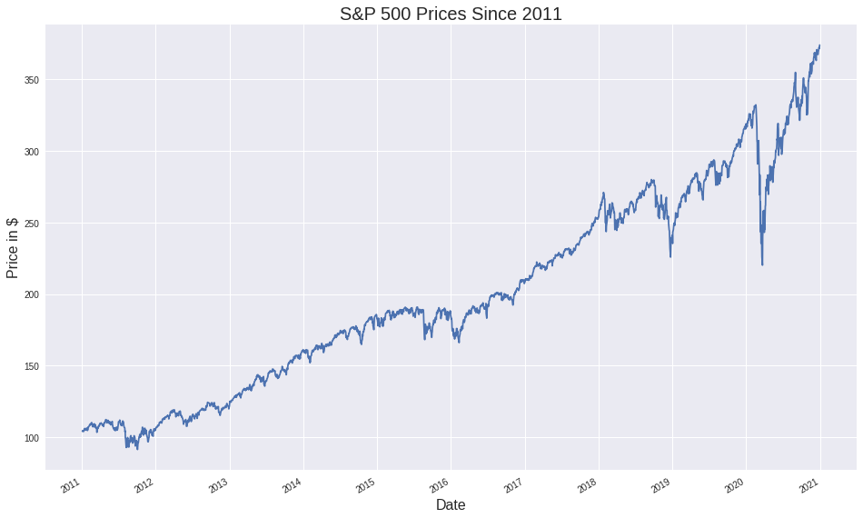

```python
plt.figure(figsize=(16,10))
plt.plot(spy['Price'], '-')
plt.gcf().autofmt_xdate()
plt.title('S&P 500 Prices Since 2011', fontsize=20)
plt.xlabel('Date', fontsize=16)
plt.ylabel('Price in $', fontsize=16)
plt.show()
```

```python
def plot_time_series(data, title, x_label, y_label):
  plt.figure(figsize=(16,10))
  plt.plot(data, '-')
  plt.gcf().autofmt_xdate()
  plt.title(title, fontsize=20)
  plt.xlabel(x_label, fontsize=16)
  plt.ylabel(y_label, fontsize=16)
  plt.show()
```

```python
import numpy as np
```

```python
price_2010 = spy['Price'][0]
price_2021 = spy['Price'][-1]
roi = np.log(price_2021 / price_2010) * 100 # Logarithmic Return
print(f'Price on {spy.index[0].strftime("%d-%m-%Y")}: ${round(price_2010, 2)}')
print(f'Price on {spy.index[-1].strftime("%d-%m-%Y")}: ${round(price_2021, 2)}')
print(f'Return of Investment: {round(roi, 2)}%')
```

```
Price on 03-01-2011: $104.12
Price on 31-12-2020: $373.88
Return of Investment: 127.84%
```

## C. Data Analysis

By doing a quick look at the data, there is some work to do before it can be used. One of them is to find the return of investment from each day. This is a necessary step. In investment, the stock price of any given day is not particularly relevant. The price difference of 2 different day prices is.

```python
spy['Price d+1'] = spy['Price'].shift(-1)
spy['ROI'] = np.log(spy['Price d+1'] / spy['Price']) * 100
spy
```

| Date | Price | Price d+1 | ROI |
| --- | --- | --- | --- |
| 2011-01-03 | 104.119293 | 104.061905 | -0.055133 |
| 2011-01-04 | 104.061905 | 104.602806 | 0.518442 |
| 2011-01-05 | 104.602806 | 104.397934 | -0.196049 |
| 2011-01-06 | 104.397934 | 104.193031 | -0.196464 |
| 2011-01-07 | 104.193031 | 104.061905 | -0.125929 |
| ... | ... | ... | ... |
| 2020-12-24 | 369.000000 | 372.170013 | 0.855413 |
| 2020-12-28 | 372.170013 | 371.459991 | -0.190961 |
| 2020-12-29 | 371.459991 | 371.989990 | 0.142578 |
| 2020-12-30 | 371.989990 | 373.880005 | 0.506796 |
| 2020-12-31 | 373.880005 | NaN | NaN |

2517 rows × 3 columns

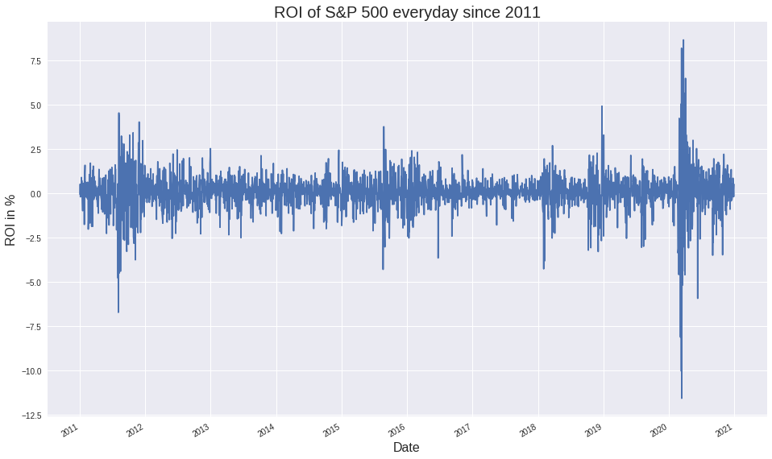

```python
plot_time_series(spy['ROI'], 'ROI of S&P 500 everyday since 2011', 'Date', 'ROI in %')
```

By looking at the graph above, although a little bit hard to distinguish it, there are several clues that can be taken. For instance, the worst ROI happened around 2020 where it was less than -10%. However, the best day came also around 2020 where the ROI exceeded 8% in one day. Next, in the beginning, stated that the analysis will be used to invest in a long term interval. This means a daily ROI will be less relevant since it is too short of interval. Resampling is a good way to convert the data from daily ROI into a monthly ROI.

```python
spy = spy[['ROI']].resample('1M').sum()
spy
```

| Date | ROI |
| --- | --- |
| 2011-01-31 | 2.862943 |
| 2011-02-28 | 0.145257 |
| 2011-03-31 | 2.114825 |
| 2011-04-30 | 2.279493 |
| 2011-05-31 | -3.245466 |
| ... | ... |
| 2020-08-31 | 6.991502 |
| 2020-09-30 | -4.113771 |
| 2020-10-31 | -2.050301 |
| 2020-11-30 | 10.298938 |
| 2020-12-31 | 2.550054 |

120 rows × 1 columns

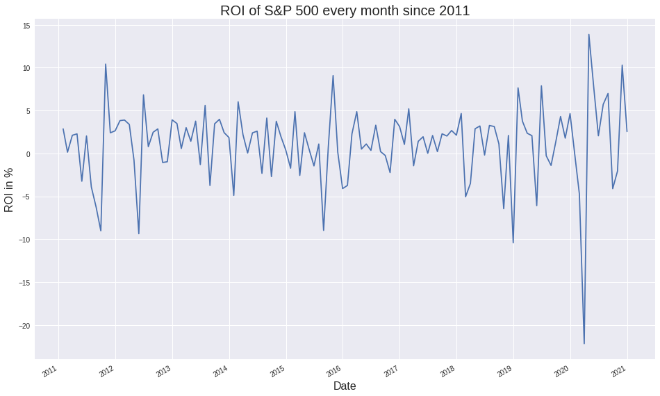

```python
plot_time_series(spy['ROI'], 'ROI of S&P 500 every month since 2011', 'Date', 'ROI in %')
```

```python
spy.describe()
```

|  | ROI |
| --- | --- |
| count | 120.000000 |
| mean | 1.065331 |
| std | 4.537168 |
| min | -22.182820 |
| 25% | -0.826630 |
| 50% | 2.032704 |
| 75% | 3.311488 |
| max | 13.876344 |

From the visualization and summary above, now the data looks a little bit easier to read. For instance, although the ROI is going up and down, they are not far from a certain point. It is called oscillation. The middle value of that oscillation is the mean of data, for this example is 1.06. This also means, on average, one can expect 1% ROI every month throughout the 10 years period. Then, the oscillation also has the upper bound and lower bound, and that is called standard deviation or std. With a little modification to the code, they all can be visualized as follows:

```python
def plot_time_series_with_summary(data, title, x_label, y_label):
  plt.figure(figsize=(16,10))
  plt.plot(data, '-')
  plt.gcf().autofmt_xdate()
  plt.axhline(y=data.mean(), label='Mean', color='r')
  plt.fill_between(data.index, (data.mean()-data.std()), (data.mean()+data.std()), color='b', alpha=.1, label='Volatility')
  plt.title(title, fontsize=20)
  plt.xlabel(x_label, fontsize=16)
  plt.ylabel(y_label, fontsize=16)
  plt.legend()
  plt.show()
```

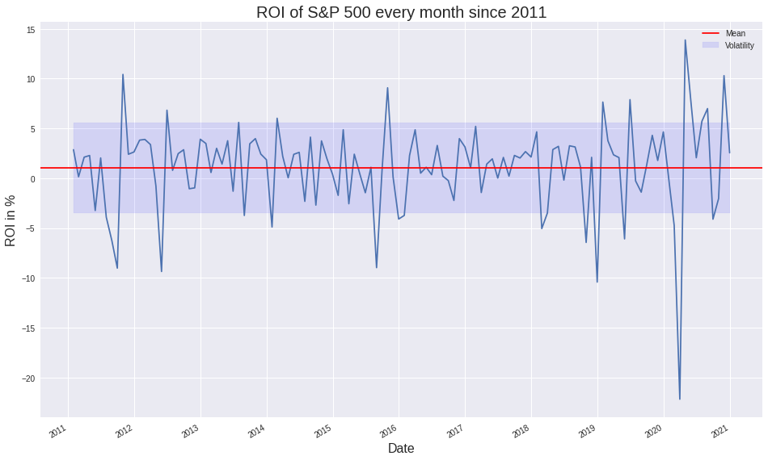

```python
plot_time_series_with_summary(spy['ROI'], 'ROI of S&P 500 every month since 2011', 'Date', 'ROI in %')
```

In stock price, the std is called volatility. This is an important metric because when a huge amount of money is involved, less volatile stock is more favorable. Less volatile stock means it is easier to predict because the risk is also lower. Even more, if the data is normally distributed, one can be sure that roughly 68% of the data point will fall inside the volatility area. So, another graph to determine if this time series data is normally distributed. One of many that fits is Q-Q plot.

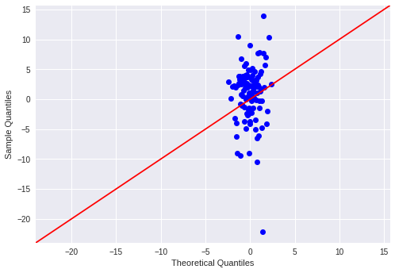

```python
import statsmodels.api as sm
sm.qqplot(spy, line ='45').show()
```

Using [statsmodels](https://www.statsmodels.org/stable/index.html) library, [Q-Q plot](https://en.wikipedia.org/wiki/Q%E2%80%93Q_plot) should show if a dataset is normally distributed. If most of the dots fall on the red line, then the distribution is normally distributed. Unfortunately, not this data. So in short, gathering data of a stock in a 10 years period can result in a rough estimation to produce an expectation of what the ROI and risk are using Average and Standard Deviation. However, in order to determine if the risk and ROI are high or low, comparison with other stocks are needed.

## D. Bulk Data Collection

As stated above, comparison with other stocks is needed to determine if a stock is relatively volatile or not. After gathering some top ETF and stocks in United States, and also some top stocks from [Indonesian Stock Exchange](https://www.indopremier.com/ipotgo/listsaham.php?page=listview&order=toppick), the data is collected and processed exactly the same as before. Then, the data is kept using [Pandas](https://pandas.pydata.org/) DataFrame for further analysis.

```python
import pandas as pd
idx_tickers = [f'{idx_ticker}.JK' for idx_ticker in [
  'PTPP',
  'WIKA',
  'SMRA',
  'ASRI',
  'CTRA',
  'INCO',
  'PTBA',
  'ADRO',
  'INDF',
  'MAPI',
  'SMGR',
  'WSKT',
  'XIJI',
  'XISI',
  'ANTM',
  'BBCA',
  'BMRI',
  'TLKM',
  'BBRI'
]] # Indonesian Stock Exchange Stocks
tickers = ['AAPL', '^DJI', 'SPY', '^JKLQ45', 'NDAQ', 'GC=F', 'CL=F', 'KO', 'RTY=F', 'MMM', 'WMT', 'COST', 'QQQ', 'MCD', 'JNJ'] + idx_tickers
```

```python
tickers_data = [] # Ticker, Average, Std, Data Length
tickers_prices = {} # Ticker data for the Calculator Website
tickers_df = {} # Historical ROI in Pandas DataFrame
for ticker in tickers:
  # Looping through all tickers
  try:
    # Fetch data using Pandas Data Reader and Yahoo Finance
    raw_data = web.DataReader(ticker, 'yahoo', start='2011-01-01', end='2021-01-01')[['Adj Close']].rename(columns={'Adj Close': 'Price'}).copy()
    # Add the next day price for later use to determine ROI per day
    raw_data['d+1'] = raw_data['Price'].shift(-1)
    # Calculate ROI for each day
    raw_data['ROI'] = np.log(raw_data['d+1'] / raw_data['Price']) * 100
    # Convert from Daily RIO into monthly ROI
    monthly_price = raw_data.resample('1M').sum()
    # Determine the upper and lower bound of Margin of Error (Website Purposes)
    monthly_price['lower'] = monthly_price['ROI'] - monthly_price['ROI'].std()
    monthly_price['upper'] = monthly_price['ROI'] + monthly_price['ROI'].std()
    tickers_prices[ticker] = {
        # Saving metrics (Website Purposes)
        'Average': monthly_price['ROI'].mean(),
        'Volatility': monthly_price['ROI'].std(),
        'Data Length': len(monthly_price['ROI']),
        'Data': {
            'Changes': monthly_price['ROI'].values.tolist(),
            'Margin of Error': monthly_price[['lower', 'upper']].values.tolist()
        }
    }
    # Saving the data into the declared valriables above to be used later
    tickers_data.append([ticker, monthly_price['ROI'].mean(), monthly_price['ROI'].std(), len(monthly_price['ROI'])])
    tickers_df[ticker] = monthly_price
  except Exception as e:
    # Catch error in order to prevent interuption of the for loop.
    print(e)
    print(ticker)
```

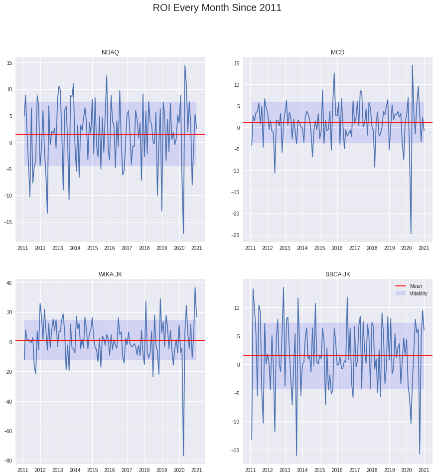

```python
sample_tickers = ['NDAQ', 'MCD', 'WIKA.JK', 'BBCA.JK']
counter = 0
figure, axis = plt.subplots(2, 2, figsize=(15,15))
figure.suptitle(' ROI Every Month Since 2011 ', fontsize=20)
for i in range(2):
  for j in range(2):
    data = tickers_df[sample_tickers[counter]]['ROI']
    axis[i, j].plot(data, '-')
    axis[i, j].axhline(y=data.mean(), label='Mean', color='r')
    axis[i, j].fill_between(data.index, (data.mean()-data.std()), (data.mean()+data.std()), color='b', alpha=.1, label='Volatility')
    axis[i, j].set_title(f'{sample_tickers[counter]}')
    counter += 1
plt.legend()
plt.show()
```

## E. Data Selection

By comparing side by side, the real difference between each stock will appear more clearly. Quick observation shows MCD stock looks more stable compared to Nasdaq. In order to give an overall overview, plotting average against volatility from each stock is needed.

```python
df_tickers_data = pd.DataFrame(tickers_data, columns=['Ticker', 'Average', 'Volatility', 'Data Length'])
```

```python
df_tickers_data.sample(10)
```

|  | Ticker | Average | Volatility | Data Length |
| --- | --- | --- | --- | --- |
| 14 | JNJ | 1.009873 | 4.465456 | 120 |
| 5 | GC=F | 0.238108 | 4.685853 | 120 |
| 21 | PTBA.JK | 0.046854 | 12.070071 | 120 |
| 22 | ADRO.JK | -0.163046 | 12.304009 | 120 |
| 33 | BBRI.JK | 1.384867 | 8.858044 | 120 |
| 11 | COST | 1.602295 | 4.631703 | 120 |
| 32 | TLKM.JK | 0.790640 | 6.149449 | 120 |
| 0 | AAPL | 2.141814 | 8.307274 | 120 |
| 8 | RTY=F | 0.804285 | 8.147367 | 42 |
| 16 | WIKA.JK | 1.096776 | 13.383948 | 120 |

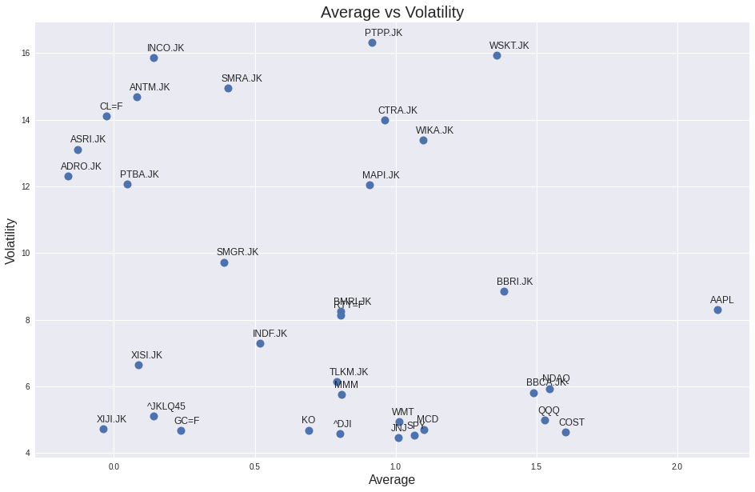

```python
plt.figure(figsize=(16,10))
plt.plot(df_tickers_data['Average'], df_tickers_data['Volatility'], '.', markersize=20)
plt.title('Average vs Volatility', fontsize=20)
for i in range(len(df_tickers_data)):
    txt = df_tickers_data['Ticker'][i]
    x = df_tickers_data['Average'][i]
    y = df_tickers_data['Volatility'][i]
    plt.annotate(txt, (x - .025, y + 0.2), fontsize=12)
plt.xlabel('Average', fontsize=16)
plt.ylabel('Volatility', fontsize=16)
plt.show()
```

Now, it is clear that, although a stock has a huge average ROI month to month, it does not necessarily mean it is the best stock to choose. Especially, when the stock has volatility. For example WSKT.JK Stock, the average ROI is around 1.3% each month. However, during that each month, the price of WSKT.JK stock can increase or decrease for around 16%. It happens also the other way around. High volatility does not necessary mean a huge return. Taking for example INCO stock. With a return less than 0.5% a month, the volatility can go up to 16%. For a long term investment, such volatility is uncessasary high.

```python
df_tickers_data.describe()
```

|  | Average | Volatility | Data Length |
| --- | --- | --- | --- |
| count | 34.000000 | 34.000000 | 34.000000 |
| mean | 0.750536 | 8.875950 | 114.352941 |
| std | 0.586231 | 4.200144 | 15.933350 |
| min | -0.163046 | 4.465456 | 42.000000 |
| 25% | 0.165950 | 4.957546 | 120.000000 |
| 50% | 0.804192 | 7.721990 | 120.000000 |
| 75% | 1.088915 | 12.910809 | 120.000000 |
| max | 2.141814 | 16.322124 | 120.000000 |

In order to determine a definitive baseline, the mean of volatility and average ROI can be used. Below is the visualization of it:

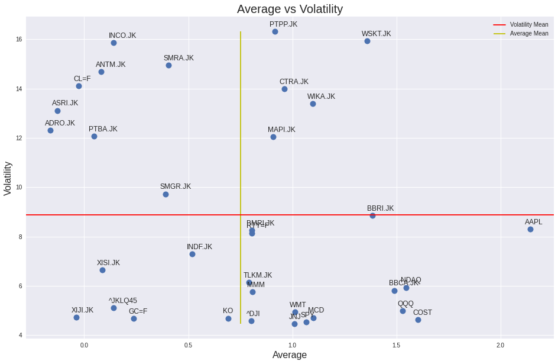

```python
plt.figure(figsize=(16,10))
plt.plot(df_tickers_data['Average'], df_tickers_data['Volatility'], '.', markersize=20)
plt.title('Average vs Volatility', fontsize=20)
for i in range(len(df_tickers_data)):
    txt = df_tickers_data['Ticker'][i]
    x = df_tickers_data['Average'][i]
    y = df_tickers_data['Volatility'][i]
    plt.annotate(txt, (x - .025, y + 0.2), fontsize=12)
plt.axhline(y=df_tickers_data['Volatility'].mean(), label='Volatility Mean', color='r')
plt.vlines(x=df_tickers_data['Average'].mean(), label='Average Mean', color='y', ymin = (min(df_tickers_data['Volatility'])), ymax= (max(df_tickers_data['Volatility'])))
plt.xlabel('Average', fontsize=16)
plt.ylabel('Volatility', fontsize=16)
plt.legend()
plt.show()
```

The decision can be as arbitrary as possible. Since the purpose of data analysis is to inform the decision maker. So, for this specific data analysis, a stock that has volatility higher than average is considered a high risk stock. That also applies to average ROI, if a stock has an average RIO below the mean, then it is considered less profitable. Therefore, a cut off value can be set at both values which result in below stocks:

```python
selected_df = df_tickers_data[df_tickers_data['Average'] > df_tickers_data['Average'].mean()]
selected_df = selected_df[selected_df['Volatility'] < df_tickers_data['Volatility'].mean()].reset_index(drop=True)
selected_df
```

|  | Ticker | Average | Volatility | Data Length |
| --- | --- | --- | --- | --- |
| 0 | AAPL | 2.141814 | 8.307274 | 120 |
| 1 | ^DJI | 0.803438 | 4.580251 | 120 |
| 2 | SPY | 1.065331 | 4.537168 | 120 |
| 3 | NDAQ | 1.547152 | 5.937020 | 120 |
| 4 | RTY=F | 0.804285 | 8.147367 | 42 |
| 5 | MMM | 0.808376 | 5.767150 | 120 |
| 6 | WMT | 1.011315 | 4.943944 | 120 |
| 7 | COST | 1.602295 | 4.631703 | 120 |
| 8 | QQQ | 1.530580 | 4.998351 | 120 |
| 9 | MCD | 1.100610 | 4.713510 | 120 |
| 10 | JNJ | 1.009873 | 4.465456 | 120 |
| 11 | BBCA.JK | 1.489972 | 5.820189 | 120 |
| 12 | BMRI.JK | 0.804099 | 8.255900 | 120 |
| 13 | TLKM.JK | 0.790640 | 6.149449 | 120 |
| 14 | BBRI.JK | 1.384867 | 8.858044 | 120 |

## F. Save The Selected Data

Since the output data will be used for a website, the output data will be stored as a JSON file.

```python
selected_data = {key.split('.')[0]:tickers_prices[key] for key in selected_df['Ticker'].values}
```

```python
from json import dump
with open('/content/drive/MyDrive/Colab Notebooks/data.json', 'w') as outfile:
    dump(selected_data, outfile)
```

# **About Author**

[figure not shown]

Coming from Indonesia, Jimmy dreams of fostering pride in the people of his country. He hopes that one day he will help Indonesia in supporting action to create equity in wealth, education and human rights. That is why he builds a [YouTube Channel](https://www.youtube.com/channel/UCYM0upJeTCi89Yi59JbMeqw) where Indonesian people can learn together to solve problems using code.

[LinkedIn](https://www.linkedin.com/in/faza-jimmy-hikmatullah-48bb54152/) · [Personal Website](https://jimmyganteng.com) · [Investing Calculator](https://investasi.jimmyganteng.com) · [Github](https://github.com/Fazatholomew) · Email

Jimmy Hikmatullah  
2021